# QTW FINAL CASE STUDY SUMMER 2020

```r
#data manipulation
library(tidyverse)
library(dplyr)
library(data.table)
#visualization
library(ggplot2)
library(skimr)
library(corrplot)
#prediction
library(RSNNS) #older
library(neuralnet) #newer
library(randomForest)
#analysis
library(caret) #one hot encoding
```

data from - https://smu.box.com/s/k9x192jxm39enjw2wx8ouw2kopx33l32 classify column ‘y’ using features x0-x49 minimize cost on a theorhetical unknown dataset, where false positive = -10$ false negative = -500$ true positive/negative = -0$

include- confusion plot with costs average/predicted as a model metric

```r
#file_name = file.choose()
#data_raw = read.csv(file_name)
data_raw = read.csv('D:/SMU/DS 7333 Quantify The World/qtw_final_project.csv')
```

cleaning section and eda

```r
#eda with skimr
skim(data_raw) %>% dplyr::select(skim_type, skim_variable, n_missing)
```

```
-- Data Summary ------------------------
                           Values
Name                       data_raw
Number of rows             160000
Number of columns          51
_______________________
Column type frequency:
  character                5
  numeric                  46
________________________
Group variables            None

-- Variable type: character ---------------------------------------------------------------------------------------------
# A tibble: 5 x 2
  skim_variable n_missing
```

[output cut: 57 more lines]

```r
skim(data_raw) %>% dplyr::select(skim_type, skim_variable, numeric.mean)
```

```
-- Data Summary ------------------------
                           Values
Name                       data_raw
Number of rows             160000
Number of columns          51
_______________________
Column type frequency:
  character                5
  numeric                  46
________________________
Group variables            None

-- Variable type: character ---------------------------------------------------------------------------------------------
# A tibble: 5 x 1
  skim_variable
```

[output cut: 57 more lines]

```r
#add additional skimr output here
```

most columns look like they are missing a few, less than triple digits. Likely not significant next to the 160K total rows

also note that the average value of y is 0.401, indicating only ~40% of rows have y = 1

```r
#remove rows with na
data_v1 <- data_raw[complete.cases(data_raw), ]
dim(data_v1)
```

```
[1] 158534     51
```

from 160,000 to 158,534, removing all rows with NA loses 1,500 ish rows, or 0.9% of data

```r
#col 37 is dollar amounts stored as characters, need to convert
data_v1$x37 <- as.numeric(substr(data_v1$x37, 2, nchar(data_v1$x37))) #index string with substring to cut out the dollar sign and convert to numeric
#same for col 32
data_v1$x32 <- as.numeric(substr(data_v1$x32, 1, nchar(data_v1$x32)-1)) #same thing
```

ok, now we have numeric values for x37 instead of characters, run na removal again

```r
data_v1 <- data_v1[complete.cases(data_v1), ]
dim(data_v1)
```

```
[1] 158480     51
```

```r
# #isolate numeric columns only
# numeric_only <- data_v1[, unlist(lapply(data_v1, is.numeric))]
# #corrplot
# cor1 <- cor(numeric_only)
# corrplot(cor1, method = 'circle')
# ggsave('corplot1.png', device = 'png', plot = last_plot(), dpi = 300, width = 10, height = 10, units = 'in')
# #saves to wherever getwd() is pointing
```

also note that rows 2/6 and 38/41 are closely correlated, may be able to eliminate one

```r
#looking at number of categorical variables in each non-numeric column
non_numeric_only <- data_v1[, !unlist(lapply(data_v1, is.numeric))]

for(i in 1:length(non_numeric_only)){
  print(table(non_numeric_only[, i]))
}
```

```
        america    asia  euorpe
     28    4420  137651   16381

            Apr     Aug     Dev     Feb January    July     Jun     Mar     May     Nov     Oct   sept.
     30    6701   29125      23     139       9   45140   40922    1221   21711     332    2385   10742

             friday    monday   thurday   tuesday wednesday
       30       556       484     29172     27697    100541
```

```r
#assign numeric values to each reigon, asia, america, 'euorpe'
temp_labels <- unique(non_numeric_only$x24)
tc = non_numeric_only$x24 #target column
for(i in 1:length(tc)){
  if(tc[i] == temp_labels[1]){
    encoded_value <- 1
  }
  if(tc[i] == temp_labels[2]){
    encoded_value <- 2
  }
  if(tc[i] == temp_labels[3]){
    encoded_value <- 3
  }
  if(tc[i] == temp_labels[4]){
    encoded_value <- 4
  }
  else{
    #encoded_value <- NA
  }
  tc[i] <- encoded_value
}
temp_labels
```

```
[1] "euorpe"  "asia"    "america" ""
```

```r
table(tc)
```

```
tc
     1      2      3      4
 16381 137651   4420     28
```

```r
reigon_numeric <- as.factor(tc) #store for later integration
```

```r
#monthly encoding
temp_labels <- unique(non_numeric_only$x29)
tc = non_numeric_only$x29 #target column
for(i in 1:length(tc)){
  if(tc[i] == 'January'){
    encoded_value <- 1}
  if(tc[i] == 'Feb'){
    encoded_value <- 2}
  if(tc[i] == 'Mar'){
    encoded_value <- 3}
  if(tc[i] == "Apr"){
    encoded_value <- 4}
  if(tc[i] == "May"){
    encoded_value <- 5}
  if(tc[i] == "Jun"){
    encoded_value <- 6}
  if(tc[i] == "July"){
    encoded_value <- 7}
  if(tc[i] == "Aug"){
    encoded_value <- 8}
  if(tc[i] == "sept."){
    encoded_value <- 9}
  if(tc[i] == "Oct"){
    encoded_value <- 10}
  if(tc[i] == "Nov"){
    encoded_value <- 11}
  if(tc[i] == "Dev"){
    encoded_value <- 12}
  if(tc[i] == ""){
    encoded_value <- 13}

  tc[i] <- encoded_value
}
temp_labels
```

```
 [1] "July"    "Aug"     "Jun"     "May"     "sept."   "Apr"     "Nov"     "Oct"     ""        "Mar"     "Feb"
[12] "Dev"     "January"
```

```r
table((non_numeric_only$x29))
```

```
            Apr     Aug     Dev     Feb January    July     Jun     Mar     May     Nov     Oct   sept.
     30    6701   29125      23     139       9   45140   40922    1221   21711     332    2385   10742
```

```r
table(tc)
```

```
tc
    1    10    11    12    13     2     3     4     5     6     7     8     9
    9  2385   332    23    30   139  1221  6701 21711 40922 45140 29125 10742
```

```r
month_numeric <-as.factor(tc) #store for later integration
```

ok, sorted months match up

```r
#day of week encoding
temp_labels <- unique(non_numeric_only$x30)
tc = non_numeric_only$x30 #target column
for(i in 1:length(tc)){
  if(tc[i] == 'monday'){
    encoded_value <- 1}
  if(tc[i] == 'tuesday'){
    encoded_value <- 2}
  if(tc[i] == 'wednesday'){
    encoded_value <- 3}
  if(tc[i] == 'thurday'){
    encoded_value <- 4}
  if(tc[i] == 'friday'){
    encoded_value <- 5}
  if(tc[i] == ''){
    encoded_value <- 6}
  tc[i] <- encoded_value
}
temp_labels
```

```
[1] "tuesday"   "wednesday" "thurday"   "monday"    "friday"    ""
```

```r
table((non_numeric_only$x30))
```

```
             friday    monday   thurday   tuesday wednesday
       30       556       484     29172     27697    100541
```

```r
table(tc)
```

```
tc
     1      2      3      4      5      6
   484  27697 100541  29172    556     30
```

```r
weekday_numeric <-as.factor(tc) #store for later integration
```

‘thurday’ <—– anyways, same matchups, looks correct

not too many labels to one hot encode

```r
#from caret
dmy24 <- dummyVars(" ~ .", data = non_numeric_only)
trsf24 <- data.frame(predict(dmy24, newdata = non_numeric_only))
head(trsf24)
```

|  | x24 | x24america | x24asia | x24euorpe | x29 | x29Apr | x29Aug | x29Dev | x29Feb | x29January | x29July | x29Jun | x29Mar | x29May | x29Nov | x29Oct | x29sept. | x30 | x30friday | x30monday | x30thurday | x30tuesday | x30wednesday |
| --- | --- | --- | --- | --- | --- | --- | --- | --- | --- | --- | --- | --- | --- | --- | --- | --- | --- | --- | --- | --- | --- | --- | --- |
| 1 | 0 | 0 | 0 | 1 | 0 | 0 | 0 | 0 | 0 | 0 | 1 | 0 | 0 | 0 | 0 | 0 | 0 | 0 | 0 | 0 | 0 | 1 | 0 |
| 2 | 0 | 0 | 1 | 0 | 0 | 0 | 1 | 0 | 0 | 0 | 0 | 0 | 0 | 0 | 0 | 0 | 0 | 0 | 0 | 0 | 0 | 0 | 1 |
| 3 | 0 | 0 | 1 | 0 | 0 | 0 | 0 | 0 | 0 | 0 | 1 | 0 | 0 | 0 | 0 | 0 | 0 | 0 | 0 | 0 | 0 | 0 | 1 |
| 4 | 0 | 0 | 1 | 0 | 0 | 0 | 0 | 0 | 0 | 0 | 1 | 0 | 0 | 0 | 0 | 0 | 0 | 0 | 0 | 0 | 0 | 0 | 1 |
| 5 | 0 | 0 | 1 | 0 | 0 | 0 | 0 | 0 | 0 | 0 | 1 | 0 | 0 | 0 | 0 | 0 | 0 | 0 | 0 | 0 | 0 | 1 | 0 |
| 6 | 0 | 0 | 1 | 0 | 0 | 0 | 1 | 0 | 0 | 0 | 0 | 0 | 0 | 0 | 0 | 0 | 0 | 0 | 0 | 0 | 0 | 0 | 1 |

```r
NA
```

```r
#add the columns to the actual dataset, drop the now redundant columns
data_v3 <- data_v1[, unlist(lapply(data_v1, is.numeric))] #remove x24, 29, 30
data_v3 <- cbind(data_v3, trsf24) #attach the one hot encoded data
head(data_v3)
```

|  | x0 | x1 | x2 | x3 | x4 | x5 | x6 | x7 | x8 | x9 | x10 | x11 | x12 | x13 | x14 | x15 | x16 | x17 | x18 | x19 | x20 | x21 | x22 | x23 | x25 | x26 | x27 | x28 | x31 | … |
| --- | --- | --- | --- | --- | --- | --- | --- | --- | --- | --- | --- | --- | --- | --- | --- | --- | --- | --- | --- | --- | --- | --- | --- | --- | --- | --- | --- | --- | --- | --- |
| 1 | -0.1665627 | -3.9615883 | 4.621113 | 2.481908 | -1.800135 | 0.8046842 | 6.718751 | -14.789997 | -1.0406730 | -4.2049496 | 6.18746525 | 13.251523 | 25.665413 | -5.017267 | 10.503714 | -2.5176783 | 2.117910 | 5.865923 | -6.666158 | 1.791497 | -1.909114 | -1.737940 | -2.516715 | 3.553013 | -0.8013398 | 1.1429499 | 1.0051306 | -18.473784 | -3.8516690 | … |
| 2 | -0.1498940 | -0.5856755 | 27.839856 | 4.152333 | 6.426802 | -2.4269429 | 40.477058 | -6.725709 | 0.8964210 | 0.3301654 | -11.70885866 | -2.352809 | -25.014934 | 9.799608 | -10.960705 | 1.5039999 | -2.397836 | -9.301839 | -1.999413 | 5.045258 | -5.809984 | 10.814319 | -0.478112 | 10.590601 | 0.8187919 | -0.6429867 | 0.7510861 | 3.749377 | 1.3915942 | … |
| 3 | -0.3217069 | -1.4298188 | 12.251561 | 6.586874 | -5.304647 | -11.3110898 | 17.812850 | 11.060572 | 5.3258804 | -2.6329840 | 1.57264743 | -4.170771 | 12.078602 | -5.158498 | 7.302780 | -2.1924311 | -4.065428 | -7.675055 | 4.041629 | -6.633628 | 1.700321 | -2.419221 | 2.467521 | -5.270615 | -0.7183154 | -0.5667566 | 4.1710884 | 11.522448 | -3.2620817 | … |
| 4 | -0.2455944 | 5.0766774 | -24.149632 | 3.637307 | 6.505811 | 2.2902240 | -35.111751 | -18.913592 | -0.3370413 | -5.5680762 | -2.00025501 | -19.286668 | 10.995330 | -5.914378 | 2.511400 | 1.2923616 | -2.496882 | -15.722954 | -2.735382 | 1.117536 | 1.923670 | -14.179167 | 1.470625 | -11.484431 | -0.0524298 | -0.5585825 | 9.2155691 | 30.595226 | -2.2852409 | … |
| 5 | -0.2733664 | 0.3063261 | -11.352593 | 1.676758 | 2.928441 | -0.6168245 | -16.505817 | 27.532281 | 1.1997146 | -4.3091048 | 6.66752962 | 1.965913 | -28.106348 | -1.258950 | 5.759941 | 0.4725838 | -1.150097 | -14.118709 | 4.527964 | -1.284372 | -9.026317 | -7.039818 | -1.978748 | -15.998166 | -0.2234492 | 0.3507814 | 1.8111816 | -4.094084 | 0.9210475 | … |
| 6 | -0.2267057 | 11.3503642 | 10.831367 | 5.182092 | -2.236454 | 10.7162476 | 15.747993 | -15.900329 | -0.1780023 | 10.9013056 | -0.09016951 | -6.062488 | 3.463613 | 1.853504 | -7.905793 | -1.0552429 | 0.685375 | -9.407338 | -2.437729 | -13.313062 | 5.737036 | -5.469731 | 7.534708 | 2.225120 | 0.8942638 | 0.3542656 | 14.1627353 | 5.567174 | 1.1688497 | … |

## data cleanup

so columns 24, 29, and 30 were region, month, and day of the week (weekdays only) respectively. All were one hot encoded generating additional columns for binary values for each category. 0.9% of the data was missing in some form, minimal value from imputing, so dropped instead.

now integrate these values back into another version of the data in order to do correlation analysis

```r
# data_v2 <- data_v1 #data v2 is including categorical variables not one hot encoded, numerics only
# data_v2$x24 <- reigon_numeric
# data_v2$x29 <- month_numeric
# data_v2$x30 <- weekday_numeric
#
# numeric_only <- data_v2[, unlist(lapply(data_v2, is.numeric))]
# cor2 <- cor(numeric_only)
# corrplot(cor2, method = 'circle')
```

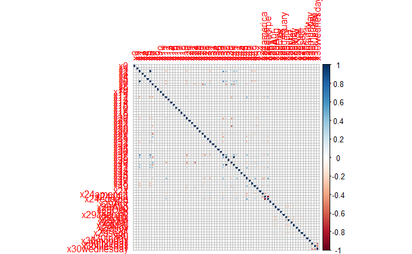

```r
cor3 <- cor(data_v3) #includes one hot encoded
corrplot(cor3, method = 'circle')
```

strong negative correlations between wedsnesday and tuesday, asia and europe 38 likely redundant with 41, 2 with 6 no strong correlation with any of the individual categorical variables and target y

NN classification test 1

```r
start.time <- Sys.time()
set.seed(123412415)
#stuttgart neural network simulator test
#where size = units in hidden layer
inputs_v3 <- data.matrix(data_v3[, -data_v3$y]) #one hot encoded set
target_v3 <- data.matrix(data_v3$y)
#inputs_v3 <- data.matrix(data_v2[, -data_v2$y]) #categorical set
#target_v3 <- data.matrix(data_v2$y)
data_v4 <- splitForTrainingAndTest(inputs_v3, target_v3, ratio = 0.3)

model1 <- mlp(data_v4$inputsTrain, data_v4$targetsTrain, size = 5, learnFuncParams = c(0.1), maxit = 50, inputsTest = data_v4$inputsTest, targetsTest = data_v4$targetsTest)

end.time <- Sys.time()
time.taken <- end.time - start.time
print(paste('time ellapsed:', time.taken))
```

```
[1] "time ellapsed: 1.16789688666662"
```

```r
summary(model1)
```

```
SNNS network definition file V1.4-3D
generated at Wed Aug 05 11:16:15 2020

network name : RSNNS_untitled
source files :
no. of units : 76
no. of connections : 355
no. of unit types : 0
no. of site types : 0


learning function : Std_Backpropagation
update function   : Topological_Order


unit default section :

act      | bias     | st | subnet | layer | act func     | out func
---------|----------|----|--------|-------|--------------|-------------
 0.00000 |  0.00000 | i  |      0 |     1 | Act_Logistic | Out_Identity
---------|----------|----|--------|-------|--------------|-------------


unit definition section :

no. | typeName | unitName           | act      | bias     | st | position | act func     | out func | sites
----|----------|--------------------|----------|----------|----|----------|--------------|----------|-------
  1 |          | Input_x1           | -0.41277 |  0.24002 | i  |  1, 0, 0 | Act_Identity |          |
  2 |          | Input_x2           | -10.91141 | -0.19267 | i  |  2, 0, 0 | Act_Identity |          |
  3 |          | Input_x3           | -5.63363 |  0.17526 | i  |  3, 0, 0 | Act_Identity |          |
  4 |          | Input_x4           | -4.02815 |  0.07636 | i  |  4, 0, 0 | Act_Identity |          |
  5 |          | Input_x5           | 15.93943 |  0.12801 | i  |  5, 0, 0 | Act_Identity |          |
  6 |          | Input_x6           | -15.86437 |  0.15784 | i  |  6, 0, 0 | Act_Identity |          |
  7 |          | Input_x7           | -46.38819 | -0.05399 | i  |  7, 0, 0 | Act_Identity |          |
  8 |          | Input_x8           | 18.33947 |  0.23142 | i  |  8, 0, 0 | Act_Identity |          |
  9 |          | Input_x9           | -4.57550 | -0.17220 | i  |  9, 0, 0 | Act_Identity |          |
 10 |          | Input_x10          | -2.97621 |  0.10207 | i  | 10, 0, 0 | Act_Identity |          |
 11 |          | Input_x11          | -8.38940 | -0.04278 | i  | 11, 0, 0 | Act_Identity |          |
 12 |          | Input_x12          | -2.60160 | -0.03880 | i  | 12, 0, 0 | Act_Identity |          |
 13 |          | Input_x13          | -8.79307 | -0.05658 | i  | 13, 0, 0 | Act_Identity |          |
```

[output cut: 97 more lines]

[output not shown]

```r
#model1
extractNetInfo(model1)
```

| name | value |
| --- | --- |
| no. of units | 76 |
| no. of connections | 355 |
| no. of unit types | 0 |
| no. of site types | 0 |
| learning function | Std_Backpropagation |
| update function | Topological_Order |

| unitNo | unitName | unitAct | unitBias | type | posX | posY | posZ | actFunc | outFunc | sites |
| --- | --- | --- | --- | --- | --- | --- | --- | --- | --- | --- |
| 1 | Input_x1 | -4.127732e-01 | 0.240023017 | UNIT_INPUT | 1 | 0 | 0 | Act_Identity | Out_Identity |  |
| 2 | Input_x2 | -1.091141e+01 | -0.192671776 | UNIT_INPUT | 2 | 0 | 0 | Act_Identity | Out_Identity |  |
| 3 | Input_x3 | -5.633629e+00 | 0.175256073 | UNIT_INPUT | 3 | 0 | 0 | Act_Identity | Out_Identity |  |
| 4 | Input_x4 | -4.028154e+00 | 0.076364100 | UNIT_INPUT | 4 | 0 | 0 | Act_Identity | Out_Identity |  |
| 5 | Input_x5 | 1.593943e+01 | 0.128008693 | UNIT_INPUT | 5 | 0 | 0 | Act_Identity | Out_Identity |  |
| 6 | Input_x6 | -1.586437e+01 | 0.157840461 | UNIT_INPUT | 6 | 0 | 0 | Act_Identity | Out_Identity |  |
| 7 | Input_x7 | -4.638819e+01 | -0.053991944 | UNIT_INPUT | 7 | 0 | 0 | Act_Identity | Out_Identity |  |
| 8 | Input_x8 | 1.833947e+01 | 0.231424212 | UNIT_INPUT | 8 | 0 | 0 | Act_Identity | Out_Identity |  |
| 9 | Input_x9 | -4.575499e+00 | -0.172197759 | UNIT_INPUT | 9 | 0 | 0 | Act_Identity | Out_Identity |  |
| 10 | Input_x10 | -2.976210e+00 | 0.102073222 | UNIT_INPUT | 10 | 0 | 0 | Act_Identity | Out_Identity |  |

[output cut: 66 more lines]

[output not shown]

[output cut: 73 more lines]

[output not shown]

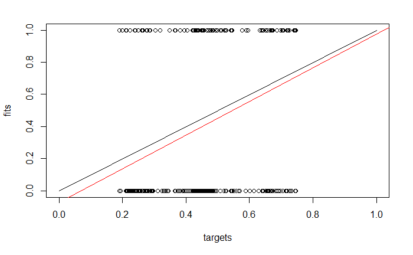

```r
plotRegressionError(model1$fittedTestValues, data_v4$targetsTest)
```

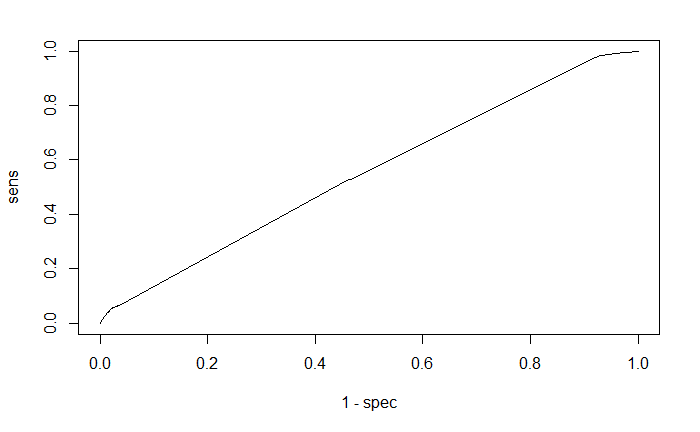

```r
plotROC(model1$fittedTestValues, data_v4$targetsTest)
```

note that model outputs predictions as a gradient between zero and one, need to round up/down to get binary data to compare against actual data false positive = -10$ false negative = -500$

problem, monetary metric is not generalizable across different test sizes, use ratio of false positve to false negative instead. functional output will be 1, confusion matrix, 2, table, 3 string output of cost estimation, 4, % negative predictions that were actually positive, 5, % positive predictions that were actually negative

```r
resultsv1 <- function(actual_values, predictions){
  ctable <- table(actual_values, predictions)
  cmat <- confusionMatrix(ctable)
  #print(cmat)
  #return(cmat)
  d_out <- (ctable[2, 1]*500 + ctable[1, 2] *10)
  s_output <- (paste('total cost of errors from model: $', format(d_out, big.mark = ',')))
  fn_chance <- ctable[2, 1]/(ctable[1, 1]+ctable[2, 1]) #%of negative predictions that are false negatives
  fp_chance <- ctable[1, 2]/(ctable[1, 2] + ctable[2, 2]) #%of positive predictions that are false positives
  return(list(cmat, s_output, d_out, fn_chance, fp_chance))
}
```

```r
train_prob <- fitted.values(model1)
train_pred <- ifelse(train_prob > 0.5, 1, 0) #round results from model to zero or one
x <- resultsv1(data_v4$targetsTrain, train_pred)
x
```

```
[[1]]
Confusion Matrix and Statistics

             predictions
actual_values     0     1
            0 64979  1430
            1 42154  2373

               Accuracy : 0.6071
                 95% CI : (0.6042, 0.61)
    No Information Rate : 0.9657
    P-Value [Acc > NIR] : 1

                  Kappa : 0.0374

 Mcnemar's Test P-Value : <2e-16

            Sensitivity : 0.60653
            Specificity : 0.62398
         Pos Pred Value : 0.97847
         Neg Pred Value : 0.05329
             Prevalence : 0.96572
         Detection Rate : 0.58573
   Detection Prevalence : 0.59862
      Balanced Accuracy : 0.61525

       'Positive' Class : 0


[[2]]
[1] "total cost of errors from model: $ 21,091,300"

[[3]]
[1] 21091300

[[4]]
[1] 0.3934735

[[5]]
[1] 0.3760189
```

```r
test_prob <- model1$fittedTestValues
test_pred <- ifelse(test_prob > 0.5, 1, 0)
m1_results <- resultsv1(data_v4$targetsTest, test_pred)
show(m1_results)
```

```
[[1]]
Confusion Matrix and Statistics

             predictions
actual_values     0     1
            0 27841   646
            1 17998  1059

               Accuracy : 0.6079
                 95% CI : (0.6035, 0.6123)
    No Information Rate : 0.9641
    P-Value [Acc > NIR] : 1

                  Kappa : 0.0387

 Mcnemar's Test P-Value : <2e-16

            Sensitivity : 0.60736
            Specificity : 0.62111
         Pos Pred Value : 0.97732
         Neg Pred Value : 0.05557
             Prevalence : 0.96414
         Detection Rate : 0.58558
   Detection Prevalence : 0.59917
      Balanced Accuracy : 0.61424

       'Positive' Class : 0


[[2]]
[1] "total cost of errors from model: $ 9,005,460"

[[3]]
[1] 9005460

[[4]]
[1] 0.3926351

[[5]]
[1] 0.3788856
```

so iteration one of the model doesn’t do too well in either test or training sets, 60% accuracy isn’t great encoded categorical variables has about 1% less accuracy

NN classification test 2 functions available in the RSNNS package view with - getSnnsRFunctionTable()

```r
start.time <- Sys.time()
#increasing layer size - no difference
#increase gradient descent step size - not much difference
#change learning function to backpropMomentum #slightly better, up to 70%
inputs_v3 <- data.matrix(data_v3[, -data_v3$y]) #one hot encoded set
target_v3 <- data.matrix(data_v3$y)
#inputs_v3 <- data.matrix(data_v2[, -data_v2$y])
#target_v3 <- data.matrix(data_v2$y)
data_v4 <- splitForTrainingAndTest(inputs_v3, target_v3, ratio = 0.3)

model2 <- mlp(data_v4$inputsTrain, data_v4$targetsTrain, size = 5, learnFunc = 'BackpropMomentum', learnFuncParams = c(0.1, 0.5, 0.1, 0.1), maxit = 50, inputsTest = data_v4$inputsTest, targetsTest = data_v4$targetsTest)
#for standard back propagation, parameters are stepsize of gradient descent
#for backprop momentum, parameters are stepsize, momentum, flatspot elimination, and dmax???

#parameter explainations here - http://www.ra.cs.uni-tuebingen.de/SNNS/UserManual/node52.html#SECTION00540000000000000000

summary(model2)
```

```
SNNS network definition file V1.4-3D
generated at Wed Aug 05 11:17:09 2020

network name : RSNNS_untitled
source files :
no. of units : 76
no. of connections : 355
no. of unit types : 0
no. of site types : 0


learning function : BackpropMomentum
update function   : Topological_Order


unit default section :

act      | bias     | st | subnet | layer | act func     | out func
---------|----------|----|--------|-------|--------------|-------------
 0.00000 |  0.00000 | i  |      0 |     1 | Act_Logistic | Out_Identity
---------|----------|----|--------|-------|--------------|-------------


unit definition section :

no. | typeName | unitName           | act      | bias     | st | position | act func     | out func | sites
----|----------|--------------------|----------|----------|----|----------|--------------|----------|-------
  1 |          | Input_x1           | -0.41277 |  0.25082 | i  |  1, 0, 0 | Act_Identity |          |
  2 |          | Input_x2           | -10.91141 |  0.09136 | i  |  2, 0, 0 | Act_Identity |          |
  3 |          | Input_x3           | -5.63363 |  0.05887 | i  |  3, 0, 0 | Act_Identity |          |
  4 |          | Input_x4           | -4.02815 |  0.18529 | i  |  4, 0, 0 | Act_Identity |          |
  5 |          | Input_x5           | 15.93943 |  0.27318 | i  |  5, 0, 0 | Act_Identity |          |
  6 |          | Input_x6           | -15.86437 | -0.09737 | i  |  6, 0, 0 | Act_Identity |          |
  7 |          | Input_x7           | -46.38819 | -0.16451 | i  |  7, 0, 0 | Act_Identity |          |
  8 |          | Input_x8           | 18.33947 |  0.28029 | i  |  8, 0, 0 | Act_Identity |          |
  9 |          | Input_x9           | -4.57550 |  0.00482 | i  |  9, 0, 0 | Act_Identity |          |
 10 |          | Input_x10          | -2.97621 | -0.05054 | i  | 10, 0, 0 | Act_Identity |          |
 11 |          | Input_x11          | -8.38940 |  0.04595 | i  | 11, 0, 0 | Act_Identity |          |
 12 |          | Input_x12          | -2.60160 |  0.03485 | i  | 12, 0, 0 | Act_Identity |          |
 13 |          | Input_x13          | -8.79307 | -0.18429 | i  | 13, 0, 0 | Act_Identity |          |
```

[output cut: 97 more lines]

[output not shown]

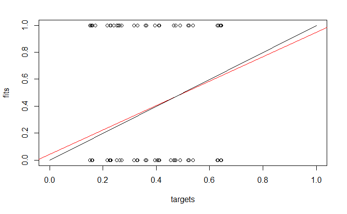

```r
plotRegressionError(model2$fittedTestValues, data_v4$targetsTest)
```

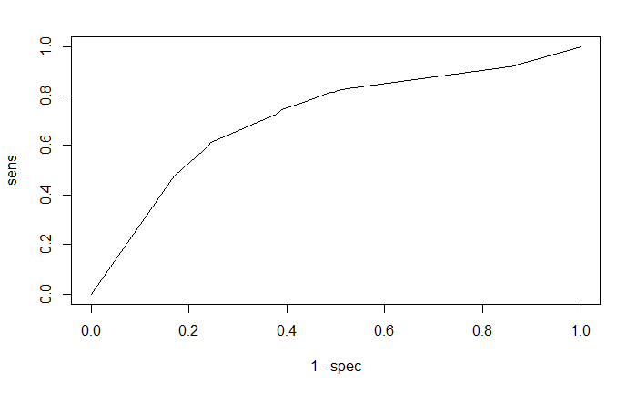

```r
plotROC(model2$fittedTestValues, data_v4$targetsTest)
```

```r
end.time <- Sys.time()
time.taken <- end.time - start.time
print(paste('time ellapsed:', time.taken))
```

```
[1] "time ellapsed: 45.5392820835114"
```

```r
train_prob <- fitted.values(model2)
train_pred <- ifelse(train_prob > 0.5, 1, 0) #round results from model to zero or one
resultsv1(data_v4$targetsTrain, train_pred)
```

```
[[1]]
Confusion Matrix and Statistics

             predictions
actual_values     0     1
            0 49891 16518
            1 17481 27046

               Accuracy : 0.6935
                 95% CI : (0.6908, 0.6962)
    No Information Rate : 0.6073
    P-Value [Acc > NIR] : < 2.2e-16

                  Kappa : 0.36

 Mcnemar's Test P-Value : 1.816e-07

            Sensitivity : 0.7405
            Specificity : 0.6208
         Pos Pred Value : 0.7513
         Neg Pred Value : 0.6074
             Prevalence : 0.6073
         Detection Rate : 0.4497
   Detection Prevalence : 0.5986
      Balanced Accuracy : 0.6807

       'Positive' Class : 0


[[2]]
[1] "total cost of errors from model: $ 8,905,680"

[[3]]
[1] 8905680

[[4]]
[1] 0.2594698

[[5]]
[1] 0.3791663
```

```r
test_prob <- model2$fittedTestValues
test_pred <- ifelse(test_prob > 0.5, 1, 0)
m1.2_results <- resultsv1(data_v4$targetsTest, test_pred)
show(m1.2_results)
```

```
[[1]]
Confusion Matrix and Statistics

             predictions
actual_values     0     1
            0 21501  6986
            1  7387 11670

               Accuracy : 0.6977
                 95% CI : (0.6935, 0.7018)
    No Information Rate : 0.6076
    P-Value [Acc > NIR] : < 2.2e-16

                  Kappa : 0.3684

 Mcnemar's Test P-Value : 0.0008485

            Sensitivity : 0.7443
            Specificity : 0.6255
         Pos Pred Value : 0.7548
         Neg Pred Value : 0.6124
             Prevalence : 0.6076
         Detection Rate : 0.4522
   Detection Prevalence : 0.5992
      Balanced Accuracy : 0.6849

       'Positive' Class : 0


[[2]]
[1] "total cost of errors from model: $ 3,763,360"

[[3]]
[1] 3763360

[[4]]
[1] 0.2557117

[[5]]
[1] 0.374464
```

switching the nn to a momentum based backpropagation function brings general accuracy up to 70%, but also greatly reduces the number of false negatives, decreasing costs

let’s iterate on that decision boundary

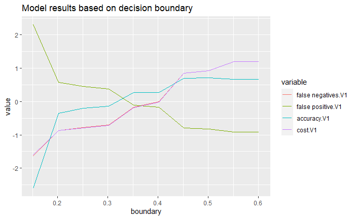

```r
#decision between 0.3 and 0.6 are necessary to avoid predicting all 1 or 0, determined by looking at range of values for predictions
#aimed at the testing split
boundary_seeker <- function(test_probability){
  blist <- seq(min(test_probability), max(test_probability), 0.05)
  fn_holder <- list()
  fp_holder <- list()
  a_holder <- list()
  d_holder <- list()
  for(i in 1:length(blist)){
    test_pred <- ifelse(test_probability > blist[i], 1, 0)
    temp1 <- resultsv1(data_v4$targetsTest, test_pred)
    fn_holder[i] <- temp1[[1]]$table[2, 1]
    fp_holder[i] <- temp1[[1]]$table[1, 2]
    a_holder[i] <- temp1[[1]]$overall[[1]] #stores the accuracy rating from the output
    d_holder[i] <- temp1[[3]] #stores dollar amount
    }
  #and visualize
  #values are scaled for the dataframe melt in order to get the cost in millions in the same neighborhood as percent accuracy
  #dataframe from flattened list of lists, indexing the results from function return got a bit messy
  btable <- data.table('boundary' = blist,
                       'false negatives' = scale(unlist(fn_holder)),
                       'false positive' = scale(unlist(fp_holder)),
                       'accuracy' = scale(unlist(a_holder)),
                       'cost' = scale(unlist(d_holder))) #don't need cost for visualization, as cost and false negatives are linear?
  btable2 <- melt(btable, id = 1) #condenses the datatable 2x col with labels for ggplot's categorical coloring
  #head(btable2)
  decision <- ggplot(btable2) +
    geom_line(aes(x = boundary, y = value, col = variable))+
    ggtitle('Model results based on decision boundary')
  show(decision)
  }

boundary_seeker(test_prob)
```

We can see that adjusting the classification boundary of the weighted output from the NN can greatly reduce cost at the expense of accuracy. The output from this function is scaled at zero in order to fit the scales of the estimated cost and accuracy on the same graph in a readable fashion. As a result the maximum values do not represent maximum accuracy or cost, just the upper range of the recorded accuracy and cost We can minimize cost at the expense of extremely high false positive rate and low accuracy; always predicting a positive is however not usually a sound strategy. the highest accuracy is comes from setting the boundary around greater than 0.5, but also has high rate of false negatives. We can see that the optimal trade-off between cost and accuracy is somewhere in the middle holding all other parameters of the model constant.

Let’s adjust the decision boundary for predictions being classified as zero or oen

```r
train_prob <- fitted.values(model2)
train_pred <- ifelse(train_prob > 0.32, 1, 0) #round results from model to zero or one
resultsv1(data_v4$targetsTrain, train_pred)
```

```
[[1]]
Confusion Matrix and Statistics

             predictions
actual_values     0     1
            0 37494 28915
            1  9849 34678

               Accuracy : 0.6506
                 95% CI : (0.6478, 0.6534)
    No Information Rate : 0.5732
    P-Value [Acc > NIR] : < 2.2e-16

                  Kappa : 0.3208

 Mcnemar's Test P-Value : < 2.2e-16

            Sensitivity : 0.7920
            Specificity : 0.5453
         Pos Pred Value : 0.5646
         Neg Pred Value : 0.7788
             Prevalence : 0.4268
         Detection Rate : 0.3380
   Detection Prevalence : 0.5986
      Balanced Accuracy : 0.6686

       'Positive' Class : 0


[[2]]
[1] "total cost of errors from model: $ 5,213,650"

[[3]]
[1] 5213650
```

```r
test_prob <- model2$fittedTestValues
test_pred <- ifelse(test_prob > 0.32, 1, 0)
resultsv1(data_v4$targetsTest, test_pred)
```

```
[[1]]
Confusion Matrix and Statistics

             predictions
actual_values     0     1
            0 16118 12369
            1  4302 14755

               Accuracy : 0.6494
                 95% CI : (0.645, 0.6536)
    No Information Rate : 0.5705
    P-Value [Acc > NIR] : < 2.2e-16

                  Kappa : 0.3178

 Mcnemar's Test P-Value : < 2.2e-16

            Sensitivity : 0.7893
            Specificity : 0.5440
         Pos Pred Value : 0.5658
         Neg Pred Value : 0.7743
             Prevalence : 0.4295
         Detection Rate : 0.3390
   Detection Prevalence : 0.5992
      Balanced Accuracy : 0.6667

       'Positive' Class : 0


[[2]]
[1] "total cost of errors from model: $ 2,274,690"

[[3]]
[1] 2274690
```

```r
m2_results <- resultsv1(data_v4$targetsTest, test_pred)
```

NN classification test 3

```r
#with tanh as activation function
inputs_v3 <- data.matrix(data_v2[, -data_v2$y])
target_v3 <- data.matrix(data_v2$y)
data_v4 <- splitForTrainingAndTest(inputs_v3, target_v3, ratio = 0.3)

model3 <- mlp(data_v4$inputsTrain, data_v4$targetsTrain, size = 5,
              initFunc = 'Randomize_Weights', initFuncParams = c(-.1, 0.1),
              learnFunc = 'BackpropMomentum', learnFuncParams = c(0.1, 0.5, 0.1, 0.1),
              hiddenActFunc = 'Act_TanH' ,
              maxit = 50,
              inputsTest = data_v4$inputsTest,
              targetsTest = data_v4$targetsTest)

summary(model3)
```

```
SNNS network definition file V1.4-3D
generated at Wed Aug 05 11:18:05 2020

network name : RSNNS_untitled
source files :
no. of units : 56
no. of connections : 255
no. of unit types : 0
no. of site types : 0


learning function : BackpropMomentum
update function   : Topological_Order


unit default section :

act      | bias     | st | subnet | layer | act func     | out func
---------|----------|----|--------|-------|--------------|-------------
 0.00000 |  0.00000 | i  |      0 |     1 | Act_Logistic | Out_Identity
---------|----------|----|--------|-------|--------------|-------------


unit definition section :

no. | typeName | unitName   | act      | bias     | st | position | act func     | out func | sites
----|----------|------------|----------|----------|----|----------|--------------|----------|-------
  1 |          | Input_x1   | -0.41277 |  0.02782 | i  |  1, 0, 0 | Act_Identity |          |
  2 |          | Input_x2   | -10.91141 |  0.05120 | i  |  2, 0, 0 | Act_Identity |          |
  3 |          | Input_x3   | -5.63363 |  0.06075 | i  |  3, 0, 0 | Act_Identity |          |
  4 |          | Input_x4   | -4.02815 | -0.00606 | i  |  4, 0, 0 | Act_Identity |          |
  5 |          | Input_x5   | 15.93943 |  0.03343 | i  |  5, 0, 0 | Act_Identity |          |
  6 |          | Input_x6   | -15.86437 |  0.07527 | i  |  6, 0, 0 | Act_Identity |          |
  7 |          | Input_x7   | -46.38819 |  0.08204 | i  |  7, 0, 0 | Act_Identity |          |
  8 |          | Input_x8   | 18.33947 |  0.09011 | i  |  8, 0, 0 | Act_Identity |          |
  9 |          | Input_x9   | -4.57550 |  0.00873 | i  |  9, 0, 0 | Act_Identity |          |
 10 |          | Input_x10  | -2.97621 |  0.00587 | i  | 10, 0, 0 | Act_Identity |          |
 11 |          | Input_x11  | -8.38940 | -0.05852 | i  | 11, 0, 0 | Act_Identity |          |
 12 |          | Input_x12  | -2.60160 | -0.09870 | i  | 12, 0, 0 | Act_Identity |          |
 13 |          | Input_x13  | -8.79307 |  0.00408 | i  | 13, 0, 0 | Act_Identity |          |
```

[output cut: 67 more lines]

[output not shown]

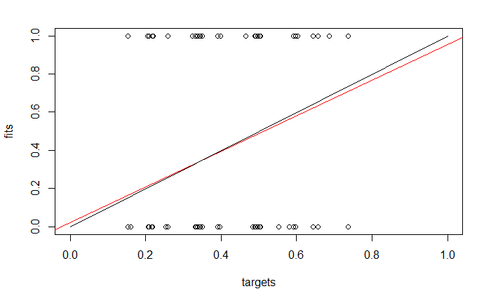

```r
plotRegressionError(model3$fittedTestValues, data_v4$targetsTest)
```

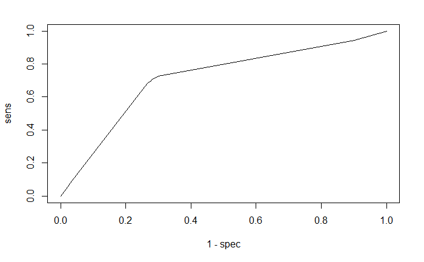

```r
plotROC(model3$fittedTestValues, data_v4$targetsTest)
```

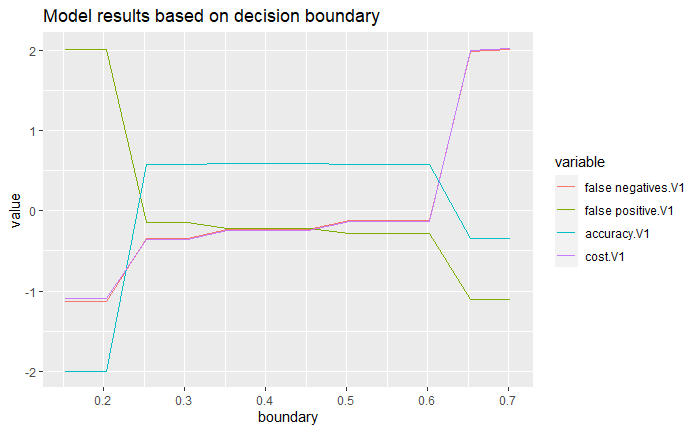

```r
boundary_seeker(model3$fittedTestValues)
```

interesting shapes here, intersection at 0.32 or 0.42 might be the the ideal balance between cost and acurracy?

```r
# boundary_value = 0.17
# train_prob <- fitted.values(model2)
# train_pred <- ifelse(train_prob > boundary_value, 1, 0) #round results from model to zero or one
# resultsv1(append(data_v4$targetsTrain, c(1, 0)), append(train_pred, c(1, 0)))

test_pred <- ifelse(test_prob > .5, 1, 0)
resultsv1(append(data_v4$targetsTest, c(1, 0)), append(test_pred, c(1, 0)))
```

```
[[1]]
Confusion Matrix and Statistics

             predictions
actual_values     0     1
            0 21502  6986
            1  7387 11671

               Accuracy : 0.6977
                 95% CI : (0.6936, 0.7018)
    No Information Rate : 0.6076
    P-Value [Acc > NIR] : < 2.2e-16

                  Kappa : 0.3685

 Mcnemar's Test P-Value : 0.0008485

            Sensitivity : 0.7443
            Specificity : 0.6256
         Pos Pred Value : 0.7548
         Neg Pred Value : 0.6124
             Prevalence : 0.6076
         Detection Rate : 0.4522
   Detection Prevalence : 0.5992
      Balanced Accuracy : 0.6849

       'Positive' Class : 0


[[2]]
[1] "total cost of errors from model: $ 3,763,360"

[[3]]
[1] 3763360
```

```r
test_prob <- model2$fittedTestValues
test_pred <- ifelse(test_prob > .32, 1, 0)
resultsv1(append(data_v4$targetsTest, c(1, 0)), append(test_pred, c(1, 0))) #adding singular instances of either class to validate mono class sorting results(it won't work normally if either entry into results v1 is all 1's or 0's)
```

```
[[1]]
Confusion Matrix and Statistics

             predictions
actual_values     0     1
            0 16119 12369
            1  4302 14756

               Accuracy : 0.6494
                 95% CI : (0.6451, 0.6537)
    No Information Rate : 0.5705
    P-Value [Acc > NIR] : < 2.2e-16

                  Kappa : 0.3178

 Mcnemar's Test P-Value : < 2.2e-16

            Sensitivity : 0.7893
            Specificity : 0.5440
         Pos Pred Value : 0.5658
         Neg Pred Value : 0.7743
             Prevalence : 0.4295
         Detection Rate : 0.3390
   Detection Prevalence : 0.5992
      Balanced Accuracy : 0.6667

       'Positive' Class : 0


[[2]]
[1] "total cost of errors from model: $ 2,274,690"

[[3]]
[1] 2274690
```

```r
test_pred <- ifelse(test_prob > .42, 1, 0)
resultsv1(append(data_v4$targetsTest, c(1, 0)), append(test_pred, c(1, 0)))
```

```
[[1]]
Confusion Matrix and Statistics

             predictions
actual_values     0     1
            0 21281  7207
            1  7234 11824

               Accuracy : 0.6963
                 95% CI : (0.6921, 0.7004)
    No Information Rate : 0.5997
    P-Value [Acc > NIR] : <2e-16

                  Kappa : 0.3675

 Mcnemar's Test P-Value : 0.8287

            Sensitivity : 0.7463
            Specificity : 0.6213
         Pos Pred Value : 0.7470
         Neg Pred Value : 0.6204
             Prevalence : 0.5997
         Detection Rate : 0.4476
   Detection Prevalence : 0.5992
      Balanced Accuracy : 0.6838

       'Positive' Class : 0


[[2]]
[1] "total cost of errors from model: $ 3,689,070"

[[3]]
[1] 3689070
```

```r
m3_results <- resultsv1(append(data_v4$targetsTest, c(1, 0)), append(test_pred, c(1, 0)))
```

NN classification test 4

```r
start.time <- Sys.time()
inputs_v3 <- data.matrix(data_v2[, -data_v2$y])
target_v3 <- data.matrix(data_v2$y)
data_v4 <- splitForTrainingAndTest(inputs_v3, target_v3, ratio = 0.3)

model4 <- mlp(data_v4$inputsTrain, data_v4$targetsTrain, size = 5, learnFunc = 'BackpropMomentum', learnFuncParams = c(0.1, 0.5, 0.1, 0.1), maxit = 50, inputsTest = data_v4$inputsTest, targetsTest = data_v4$targetsTest)

summary(model4)
```

```
SNNS network definition file V1.4-3D
generated at Wed Aug 05 11:18:53 2020

network name : RSNNS_untitled
source files :
no. of units : 56
no. of connections : 255
no. of unit types : 0
no. of site types : 0


learning function : BackpropMomentum
update function   : Topological_Order


unit default section :

act      | bias     | st | subnet | layer | act func     | out func
---------|----------|----|--------|-------|--------------|-------------
 0.00000 |  0.00000 | i  |      0 |     1 | Act_Logistic | Out_Identity
---------|----------|----|--------|-------|--------------|-------------


unit definition section :

no. | typeName | unitName   | act      | bias     | st | position | act func     | out func | sites
----|----------|------------|----------|----------|----|----------|--------------|----------|-------
  1 |          | Input_x1   | -0.41277 |  0.24237 | i  |  1, 0, 0 | Act_Identity |          |
  2 |          | Input_x2   | -10.91141 | -0.05781 | i  |  2, 0, 0 | Act_Identity |          |
  3 |          | Input_x3   | -5.63363 | -0.07811 | i  |  3, 0, 0 | Act_Identity |          |
  4 |          | Input_x4   | -4.02815 | -0.24734 | i  |  4, 0, 0 | Act_Identity |          |
  5 |          | Input_x5   | 15.93943 |  0.02688 | i  |  5, 0, 0 | Act_Identity |          |
  6 |          | Input_x6   | -15.86437 |  0.07770 | i  |  6, 0, 0 | Act_Identity |          |
  7 |          | Input_x7   | -46.38819 | -0.17638 | i  |  7, 0, 0 | Act_Identity |          |
  8 |          | Input_x8   | 18.33947 | -0.10044 | i  |  8, 0, 0 | Act_Identity |          |
  9 |          | Input_x9   | -4.57550 |  0.04942 | i  |  9, 0, 0 | Act_Identity |          |
 10 |          | Input_x10  | -2.97621 |  0.20422 | i  | 10, 0, 0 | Act_Identity |          |
 11 |          | Input_x11  | -8.38940 |  0.29107 | i  | 11, 0, 0 | Act_Identity |          |
 12 |          | Input_x12  | -2.60160 | -0.08606 | i  | 12, 0, 0 | Act_Identity |          |
 13 |          | Input_x13  | -8.79307 |  0.25993 | i  | 13, 0, 0 | Act_Identity |          |
```

[output cut: 67 more lines]

[output not shown]

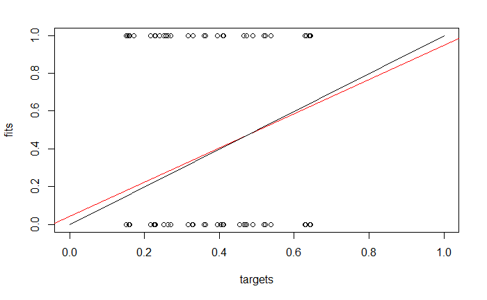

```r
plotRegressionError(model2$fittedTestValues, data_v4$targetsTest)
```

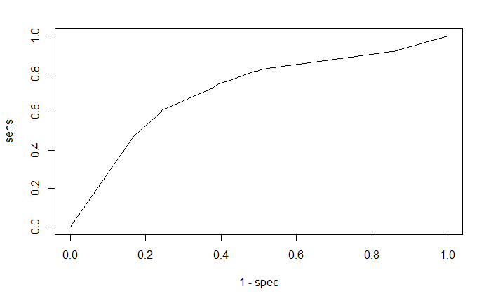

```r
plotROC(model2$fittedTestValues, data_v4$targetsTest)
```

```r
end.time <- Sys.time()
time.taken <- end.time - start.time
print(paste('time ellapsed:', time.taken))
```

```
[1] "time ellapsed: 45.3532221317291"
```

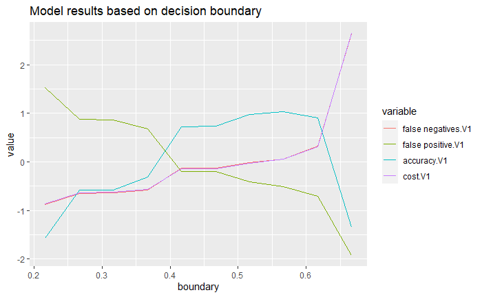

```r
boundary_seeker((model4$fittedTestValues))
```

accuracy cost tradeoff around 0.35 or 0.6

```r
# train_prob <- fitted.values(model4)
# train_pred <- ifelse(train_prob > 0.5, 1, 0) #adjust weight for class imbalance
# resultsv1(data_v4$targetsTrain, train_pred)

test_prob <- model4$fittedTestValues
test_pred <- ifelse(test_prob > 0.5, 1, 0)
resultsv1(data_v4$targetsTest, test_pred)
```

```
[[1]]
Confusion Matrix and Statistics

             predictions
actual_values     0     1
            0 21055  7432
            1  6721 12336

               Accuracy : 0.7023
                 95% CI : (0.6982, 0.7064)
    No Information Rate : 0.5842
    P-Value [Acc > NIR] : < 2.2e-16

                  Kappa : 0.3841

 Mcnemar's Test P-Value : 2.401e-09

            Sensitivity : 0.7580
            Specificity : 0.6240
         Pos Pred Value : 0.7391
         Neg Pred Value : 0.6473
             Prevalence : 0.5842
         Detection Rate : 0.4429
   Detection Prevalence : 0.5992
      Balanced Accuracy : 0.6910

       'Positive' Class : 0


[[2]]
[1] "total cost of errors from model: $ 3,434,820"

[[3]]
[1] 3434820
```

```r
test_pred <- ifelse(test_prob > 0.35, 1, 0)
m4_results <- resultsv1(data_v4$targetsTest, test_pred)
show(m4_results)
```

```
[[1]]
Confusion Matrix and Statistics

             predictions
actual_values     0     1
            0 16013 12474
            1  4272 14785

               Accuracy : 0.6478
                 95% CI : (0.6435, 0.6521)
    No Information Rate : 0.5733
    P-Value [Acc > NIR] : < 2.2e-16

                  Kappa : 0.3155

 Mcnemar's Test P-Value : < 2.2e-16

            Sensitivity : 0.7894
            Specificity : 0.5424
         Pos Pred Value : 0.5621
         Neg Pred Value : 0.7758
             Prevalence : 0.4267
         Detection Rate : 0.3368
   Detection Prevalence : 0.5992
      Balanced Accuracy : 0.6659

       'Positive' Class : 0


[[2]]
[1] "total cost of errors from model: $ 2,260,740"

[[3]]
[1] 2260740
```

```r
test_pred <- ifelse(test_prob > 0.6, 1, 0)
resultsv1(data_v4$targetsTest, test_pred)
```

```
[[1]]
Confusion Matrix and Statistics

             predictions
actual_values     0     1
            0 21517  6970
            1  7066 11991

               Accuracy : 0.7048
                 95% CI : (0.7007, 0.7089)
    No Information Rate : 0.6012
    P-Value [Acc > NIR] : <2e-16

                  Kappa : 0.3849

 Mcnemar's Test P-Value : 0.4226

            Sensitivity : 0.7528
            Specificity : 0.6324
         Pos Pred Value : 0.7553
         Neg Pred Value : 0.6292
             Prevalence : 0.6012
         Detection Rate : 0.4526
   Detection Prevalence : 0.5992
      Balanced Accuracy : 0.6926

       'Positive' Class : 0


[[2]]
[1] "total cost of errors from model: $ 3,602,700"

[[3]]
[1] 3602700
```

RSNNS is actually quite old and doesn’t natively support newer activation functions like ReLU, use package ‘neuralnet’ for model 4

```r
# #redo splits to only include certain variables
# data_v2_trim <- data_v2[sample(1:dim(data_v2)[1], size = round(0.01* dim(data_v2)[1])), ] #reduce to n percent of data for testing
# #inputs_v4 <- data.matrix(data_v2_trim[, -data_v2_trim$y]) #all columns except y
# inputs_v4 <- data.matrix(data_v2_trim[, -c(21, 23)]) #only columns 20 and 22
# target_v4 <- data.matrix(data_v2_trim$y)
# data_m4_splits <- splitForTrainingAndTest(inputs_v4, target_v4, ratio = 0.3)
```

```r
#keeps timing out, look at this later
# start.time <- Sys.time()
# #note data_v2 is the non-mixed cleaned dataset
# #looking back at the correlatin plot, lets select a few variables that appear to have the strongest correlation with Y as the initial variables for a baseline logistic regression
# #feed in test/train splits for verification data
# data_partial = data.frame(target = data_m4_splits$targetsTrain, v1 =data_m4_splits$inputsTrain[, 1], v2 = data_m4_splits$inputsTrain[, 2])
# #parameter details from - https://cran.r-project.org/web/packages/neuralnet/neuralnet.pdf
# model4 = neuralnet(target~v1+v2, data = data_partial,
#                    algorithm = 'backprop',
#                    learningrate = 0.1,
#                    rep = 10, #repetitions for training
#                    hidden = c(10), #vector of hidden layers
#                    startweights = NULL, #random intialization
#                    act.fct = 'logistic',
#                    linear.output = FALSE)
# plot(model4)
#
# end.time <- Sys.time()
# time.taken <- end.time - start.time
# print(paste('time ellapsed:', time.taken))
```

```r
# testdata4 <- data.frame(v1 =data_m4_splits$inputsTest[, 1], v2 = data_m4_splits$inputsTest[, 2])
# test_pred4 <- compute(model4, testdata4)
# #convert results to binary
# pred4 <- ifelse(test_pred4$net.result > 0.5, 1, 0) #round results from model to zero or one
# resultsv1(data_m4_splits$targetsTest, pred4)
```

model5, random forest classification

```r
start.time <- Sys.time()

data_v3_trim <- data_v3[sample(1:dim(data_v3)[1], size = round(0.10* dim(data_v3)[1])), ]
train_index <- createDataPartition(data_v3_trim$y, p = 0.7, list = FALSE)
train_v3 <- data_v3_trim[train_index, ]
train_v3$y <- as.factor(train_v3$y)
test_v3 <- data_v3_trim[-train_index, ]
test_v3$y <- as.factor(test_v3$y)

rf5 <- randomForest(y ~., data = train_v3,
                    type = 'classification',
                    proximity = TRUE,
                    importance = TRUE)
print(rf5)
```

```
Call:
 randomForest(formula = y ~ ., data = train_v3, type = "classification",      proximity = TRUE, importance = TRUE)
               Type of random forest: classification
                     Number of trees: 500
No. of variables tried at each split: 8

        OOB estimate of  error rate: 12.64%
Confusion matrix:
     0    1 class.error
0 6217  404  0.06101797
1  998 3475  0.22311648
```

```r
end.time <- Sys.time()
time.taken <- end.time - start.time
print(paste('time ellapsed:', time.taken))
```

```
[1] "time ellapsed: 2.31923568248749"
```

```r
#costs from training set
resultsv1(rf5$predicted, train_v3$y)
```

[output not shown]

pretty good for training data on only 10% data, only 5% of the predicted negatives were false negatives

apply random forest model to the test data

```r
pred5 <- predict(rf5, newdata = test_v3)
resultsv1(as.factor(test_v3$y), pred5)
```

[output not shown]

Base random forest has a fairly high accuracy and low false positive rates, double the false negative rate from the training set through, 5% to 12% for testing set. still better than any of the MLP models

note convert strings to categorical types of sampling? normalization? cross validation?

types of models (have at least one linear and nonlinear approach) use regression as baseline? NN RF (regression) RF (classification) - use this one to get a range of predictions from 0-1 and then set threshold as a method to control for class imbalance SVM(class imbalance?) glm? (linear model)

need to consider how nonlinear models have different feature space than linear models, may have different results based on the nature of the data

note, store expected costs from model classifications for graphical comparison at the end?? viz ideas - fancy colored table for confusion matrix/price matrix stacked bar chart for each model, number of type1/type2 errors and the total cost for 3 bars on each model

full model might be too complex to ship as an rshiny app, instead isolate the 5-10 most important variables and build a simple model that does a rough approximation of the prediction and display predicted outcome with confidence